# Closeread Template

This is a sample closeread document.

The narrative appears on this side bar (left margin).

The image on the right depicts three species of iris flowers and their corresponding Sepal and Petal elements.

We refer to this image element as a **sticky** element. Why? Because as you scroll down, the image of the iris flowers gets stuck in the same place.

When you trigger a sticky element, it will be displayed in the main section (to the right of this sidebar).

Here’s another sticky element. It’s a simple scatter plot based on the `iris` data set, which is a built-in data frame in R.

This narrative section is displayed as a continuous piece of text instead of being broken down into separated paragraphs.  
There are 3 species of iris flowers:  
- Setosa (red)  
- Versicolor (green)  
- Virginica (blue)

Here’s a third sticky element.

It’s just a table with summary statistics.

And finally a fourth sticky element.

A colorful plot using facets to show the distribution of Sepal Length among the three iris species.

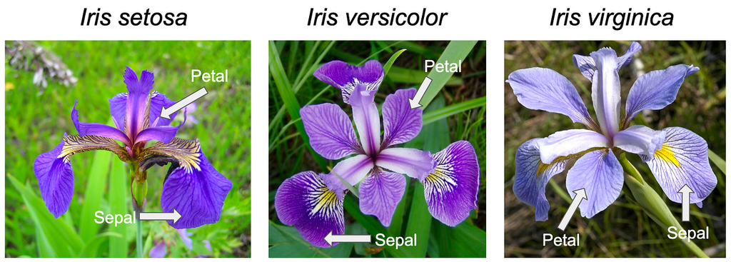

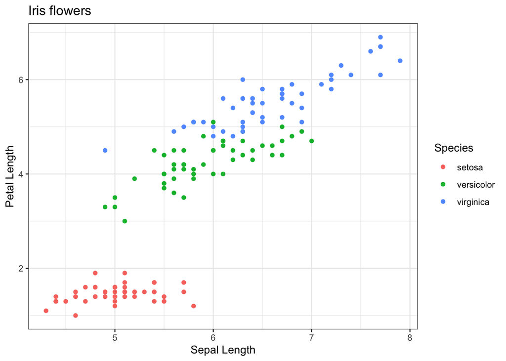

| Species | avg_sepal_length | sd_sepal_length |
| --- | --- | --- |
| setosa | 5.006 | 0.3524897 |
| versicolor | 5.936 | 0.5161711 |
| virginica | 6.588 | 0.6358796 |

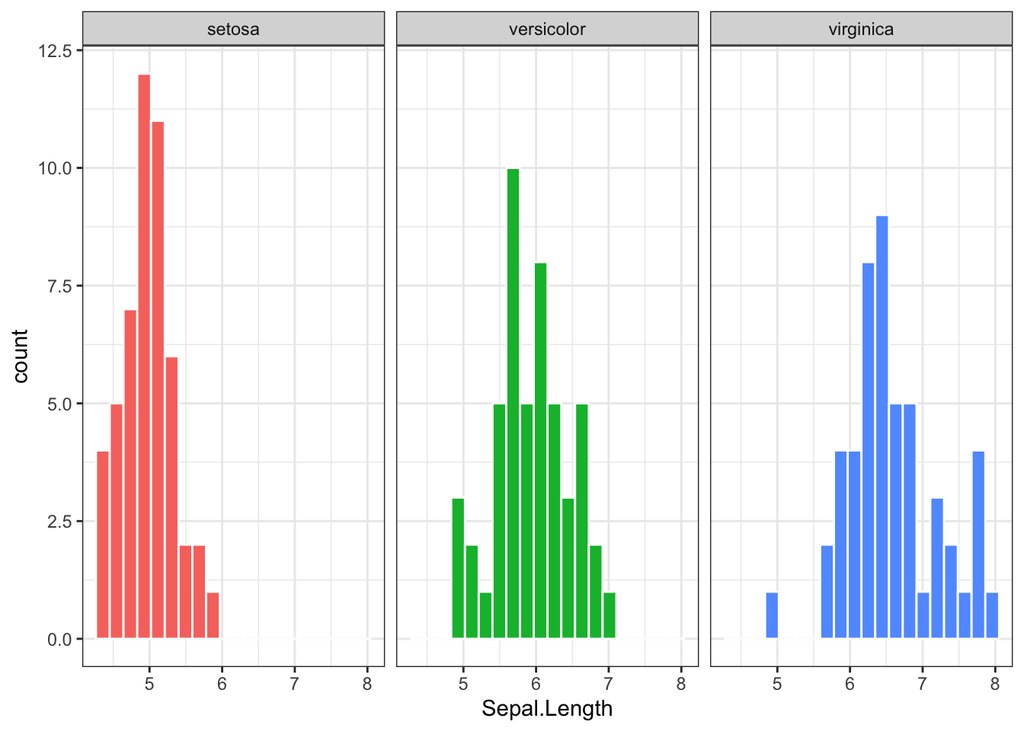